# M1 Technique de Programmation

2025-01-13

## R Présentation du Projet

Développer une application Shiny en R pour les joueurs d’échecs amateurs ou occasionnels et les aider dans leur progression

- I Recupérer les données sur les joueurs
- II Estimer le niveau des joueurs
- III Proposer une solution pour les aider à progresser

## I Récupérer les données des joueurs

- Pour ce faire, nous utiliserons les donnée de deux sites : **Chess.com** & **Lichess.com**
- Les deux sites disposent d**’API** en lecture seule sans clé d’authentification

  *Fonction de récolte des données*

```r
get_chess_com_player <- function(username) {
  base_url <- paste0("https://api.chess.com/pub/player/", username)
  response <- GET(base_url)
  if (status_code(response) == 200) {
    return(fromJSON(rawToChar(response$content)))
  }
  return(NULL)
}
```

## I.1 Récupérer les données des joueurs (Interface)

Avec les fonctions pour récupérer les informations, il nous faut alors récupérer le pseudo

[figure not shown]

## I.2 Récupérer les données des joueurs

Fonction de séparation du code par cadence pour préparer les données à l’estimation

```r
get_player_ratings <- function(chess_data, lichess_data) {
  ratings <- list(chess = list(), lichess = list())

# Chess.com ratings
if (!is.null(chess_data) && !is.null(chess_data$complete_stats)) {
if (!is.null(chess_data$complete_stats$chess_bullet)) {
ratings$chess$bullet <- chess_data$complete_stats$chess_bullet$last$rating
    }
if (!is.null(chess_data$complete_stats$chess_blitz)) {
 ratings$chess$blitz <- chess_data$complete_stats$chess_blitz$last$rating
 }
if (!is.null(chess_data$complete_stats$chess_rapid)) {
ratings$chess$rapid <- chess_data$complete_stats$chess_rapid$last$rating
    }
  }
```

## I.3 Récupérer les données des joueurs

Après avoir récupéré les informations qui nous intéressent, nous avons ajouté la possibilité pour les joueurs de se représenter graphiquement les statistiques de leur compte

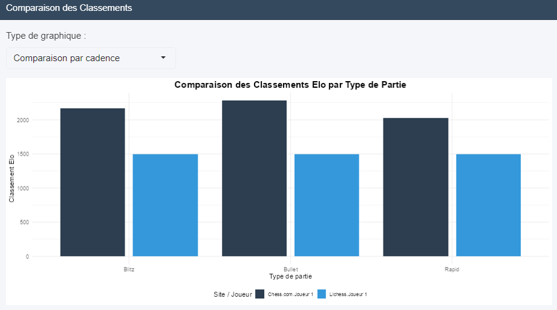

## II.1 Estimer le niveau des joueurs

Pour estimer le niveau de nos joueurs, nous nous baserons sur la norme des échecs L’Elo Fide et les données de (https://chessgoals.com/)

|  | Multiplicateur | Intercept |
| --- | --- | --- |
| FIDE | 0.7483619932 | 435.6301053 |
| Lichess-Blitz | 0.7658478335 | 616.0098942 |
| Lichess-Bullet | 0.8660009037 | 373.1784651 |
| Lichess-Rapid | 0.6298191743 | 948.7785739 |

## II.2 Estimer le niveau des joueurs (Ex)

Pour estimer un Elo FIDE à partir d’un Elo Chess.com-Bullet :

Prenons un Elo Chess.com-Bullet de **1500**. , avec la formule suivante

| *Elo estimé =(Multiplicateur×Elo donnée) + Intercept* |
| --- |

| *Elo estimé = (1.03651 x 1500 ) - 112.4543 = 1442* |
| --- |

## II.3 Estimer le niveau des joueurs (C)

En version code nous avons

```r
estimate_fide_from_lichess <- function(lichess_elo, game_type) {
  # Définition des coefficients pour Lichess
  coefficients <- list(
    bullet = list(slope = 0.8660009037, intercept = 373.1784651),
    blitz = list(slope = 0.7658478335, intercept = 616.0098942),
    rapid = list(slope = 0.6298191743, intercept = 948.7785739),
    classical = list(slope = 0.5264331886, intercept = 1070.387055)
  )
```

## II.4 Estimer le niveau des joueurs (D)

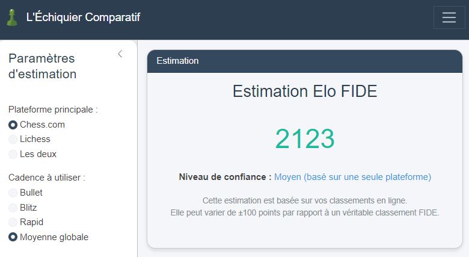

## III Proposer une solution pour aider les joueurs

**Google Book :**

- **Fonctionnalité principale** : Recherche de livres en ligne via des mots-clés, avec récupération d’informations comme le titre, l’auteur, la description et la date de publication.
- **Utilisation** : Envoi de requêtes HTTP pour obtenir des suggestions personnalisées (ex. : livres d’échecs adaptés à un Elo spécifique).

## III.1 Proposer une solution

*Exemple de demande:*

```r
search_chess_books <- function(query, api_key) {
  base_url <- "https://www.googleapis.com/books/v1/volumes"

  # Construire la requête
  full_query <- paste(query, "chess", sep = " ")

  # Faire la requête à l'API
  response <- GET(
    url = base_url,
    query = list(
      q = full_query,
      key = api_key,
      maxResults = 10
    ) )
```

| q = full_query (Recherche) , key = api_key |
| --- |

## III.2 Proposer une solution

Détermination des termes de recherche en fonction du niveau estimé des joueurs

| Débutant | < 1200 Elo | Beginner chess book |
| --- | --- | --- |
| Intermédiaire | 1200-1599 Elo | Intermediate chess book , Tactics |
| Avancé | 1600-1999 Elo | Advanced chess strategy |
| Maître | 2000-2399 | Master Chess etc … |

## III.3 Proposer une solution (C)

```r
# Déterminer le terme de recherche en fonction du niveau
search_term <- if (!is.null(fide_estimate)) {
  if (fide_estimate < 1200) {
    "beginner chess book"
  } else if (fide_estimate < 1600) {
    "intermediate chess book"
  } else if (fide_estimate < 2000) {
    "advanced chess strategy"
  } else if (fide_estimate < 2400) {
    "master chess strategy"
  } else {
    "grandmaster chess"
  }
} else {
  "chess book"  # terme par défaut si pas d'estimation
}
```

## III.4 Proposer une solution (D)

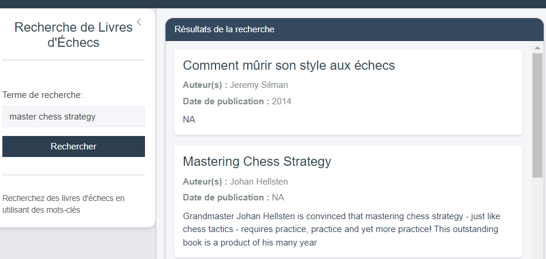

## III.5 Proposer une solution

Code de l’Echiquier d’analyse

```r
nav_panel(
    title = "Echiquier d'Analyse",
    card(
      full_screen = TRUE,
      card_header(class = "bg-primary text-white"
                  , "Echiquier d'Analyse Lichess"),
      card_body(
        tags$iframe(
          src = "https://lichess.org/analysis/embed",
          width = "100%",
          height = "800px",
          style = "border: none; border-radius: 10px;"
        )
      )
    )
  )
```

## III.6 Proposer une solution(D)

[figure not shown]

## IV Conclusion & Discussion

- **Objectif atteint** :
  - Récupérer automatiquement les données des joueurs depuis Chess.com et Lichess à partir d’un pseudo.
  - Estimer un niveau FIDE via des modèles de régression.
  - Recommander des livres adaptés au niveau de l’utilisateur grâce à l’API Google Books.
- **Avantage** : Une solution intégrée pour évaluer les performances et proposer des outils d’amélioration personnalisés.

## IV.1 Conclusion & Discussion

**Améliorations Possible**

- Nouvelles plateformes , Affinement des modèles
- Personnalisation utilisateur , Optimisation du code

Difficultés rencontrées

- Scraping sans API
- Limites API
- Uniformisation des données